# Chapter 2 - Data Preparation

## 9.2 Correlation Matrix

For many machine learning prediction tasks, what we want to know is how good feature A is going to be at predicting feature B. The correlation between two variables allows us to see quantitatively how related two variables are. A strong relationship between two variables will be a good indicator as to whether one will help predict the other.

Basic correlation measures only linear relationships between variables. If there is a relationship between the variables, but the relationship is non-linear, this may not be picked up in our correlation coefficients.

The Pearson’s product-moment coefficient - a commonly used correlation coefficient is defined between two variables $X$ and $Y$ as:

$$corr(X,Y) = \frac{cov(X,Y)}{\sigma_X \sigma_Y}$$

Where $cov(X,Y)$ is the [covariance](https://en.wikipedia.org/wiki/Covariance) between $X$ and $Y$, and $\sigma_X, \sigma_Y$ are the variances of $X$ and $Y$. For this reason you may see mentions of the covariance matrixes, a related concept.

pandas allows us to easily find the correlation coefficients between all the variables in our data frame and visualise them with a heatmap to show how strongly they are linked. Most importantly, if a feature is strongly correlated with our target variable then it is likely to be a good predictor of the target variable. We want to include features in our model that are going to be helpful to predict the target.

The relationships between the features themselves are important to us too. Beyond just understanding our data better, we can use the relationships between features to create new features.

When features are highly correlated this can introduce problems in our models. This is called “multicolinearity”, and can reduce the robustness of the resulting model. This is discussed in more depth below.

A key point about correlations is that they can only be computed between numerical data, yet another reason why our encoding of categorical data is key. (Other statistical tests are available for non-numerical data, such as a chi-squared test).

Here is an example of producing a correlation matrix plot of the numerical data in the clean_data set. We will be able to see what the relationships between the different features are.

```python
# Select only the numerical data.
numerical_data = clean_data.select_dtypes(include='number')

# Generate the correlation matrix with pandas.
correlation_matrix = numerical_data.corr()

# Show the matrix as a heatmap, matplotlib can also be used instead.
correlation_matrix.style.background_gradient(cmap='viridis').set_precision(2)
```

[output not shown]

[output not shown]

Our target in this instance is the count variable, so we are going to look at how the other features are related to the count. What we are looking for is values that are close to $+1$ or $-1$ as this shows strong positive or negative correlations, they will be good predictors. The values nearer $0$ are not as useful to us.

Looking at our map, the variables real_temperature, feel_temperature and humidity are correlated to a significant degree with the count variable. The wind_speed is less so, with a value nearer to 0.

### 9.2.1 multicollinearity

Unsurprisingly the real_temperature and the feel_temperature are nearly perfectly correlated. We do not want to include both of these in our model because that could significantly skew our results. This effect is called multicollinearity, and preventing it is an important step for many algorithms, particularly linear models.

multicollinearity occurs when one feature in a data set can be created as a result of a linear combination of other features. For example, if we created a new feature in the data set “average_temperature” which is defined as:

$$average\_temperature = 0.5 \times feel\_temperature + 0.5 \times real\_temperature$$

This is a linear combination (the features are added) which causes multicollinearity.

### 9.2.2 multicollinearity Challenges

When we have multicollinearity in the features we give a model this can cause issues with interpretability and predictive performance.

Consider if we put $feel\_temperature$ and $real\_temperature$ into a simple linear model.

If we use just one of these features to predict $count$, we can interpret the coefficient produced by the model easily.

If we use **both** features, which are highly correlated, then we might get a high coefficient value for the first feature, but not the second. Alternatively, we might get a high coefficient value for the second feature not the first. Or even, we could have middle sized coefficients for both. Whether any one these happens will depend on the small changes in data we might give to the model.

Using both highly correlated features in the model will mean that we cannot tell conclusively which feature has a bigger effect.

As a result, our model may not perform hugely worse **overall**, but it will be harder to interpret and will produce more incorrect predictions for **some individual data points**.

To remove multicollinearity in our data we have a few options. The two basic approaches are:

- drop one of the colinear features
- combine the colinear features into one feature (such as taking an average)

**Exercise 5:**

```python
# Write code here

weather_code_encoded['count'] = clean_data['count']

weather_code_corr = weather_code_encoded.corr()

# Heatmap #

weather_code_corr.style.background_gradient(cmap = 'viridis').set_precision(2)
```

[output not shown]

|  | weather_code_broken_clouds | weather_code_clear | weather_code_cloudy | weather_code_rain | weather_code_scattered_clouds | weather_code_snowfall | count |
| --- | --- | --- | --- | --- | --- | --- | --- |
| weather_code_broken_clouds | 1.00 | -0.44 | -0.12 | -0.19 | -0.27 | -0.02 | -0.06 |
| weather_code_clear | -0.44 | 1.00 | -0.19 | -0.30 | -0.43 | -0.03 | 0.05 |
| weather_code_cloudy | -0.12 | -0.19 | 1.00 | -0.08 | -0.11 | -0.01 | -0.01 |
| weather_code_rain | -0.19 | -0.30 | -0.08 | 1.00 | -0.18 | -0.01 | -0.04 |
| weather_code_scattered_clouds | -0.27 | -0.43 | -0.11 | -0.18 | 1.00 | -0.02 | 0.05 |
| weather_code_snowfall | -0.02 | -0.03 | -0.01 | -0.01 | -0.02 | 1.00 | -0.01 |
| count | -0.06 | 0.05 | -0.01 | -0.04 | 0.05 | -0.01 | 1.00 |

## 9.3 Automatic Feature Selection

Scikit-Learn comes with a function that is useful in selecting the appropriate features for your model. SelectKBest() does as the name implies, selecting the $K$ best features in your data set, where $K$ is a number the user inputs to the model. But how does SelectKBest() choose which are the best features?

There are a range of different statistical tests that can be passed to the function which will give us the best features for a certain task. For example, we can use a chi-squared test for a classification problem or an F1-score for regression, or many other options. The function then scores each feature based on how well they perform in the statistical test. From these scores it then picks the best performing features.

The SelectKBest() function requires a distinction between the features and the target data. These are typically denoted as $X$ (a matrix) and $y$ (a vector). To do this we must separate our data frame as shown below. We are also going to use a subset of the features to compare between. It is important that we get used to the $X$, $y$ notation as it is commonly used in Machine Learning to describe our feature and target sets.

```python
# Get the target data column into it's own series object.
y = clean_data['count']

# Remove the non-numerical data and the target.
X = clean_data.drop(columns=['count', 'is_weekend', 'is_holiday', 'weather_code', 'season'])
X.head()
```

|  | real_temperature | feel_temperature | humidity | wind_speed |
| --- | --- | --- | --- | --- |
| 0 | 2.75 | 0.00 | 93.00 | 7.500000 |
| 1 | 9.00 | 7.25 | 81.50 | 8.854167 |
| 2 | 8.00 | 5.75 | 79.75 | 16.000000 |
| 3 | 9.00 | 5.50 | 81.00 | 19.760870 |
| 4 | 9.00 | 6.75 | 79.50 | 20.479167 |

The target data count is a continuous variable, so we are going to use regression to predict its value. In order to select the features we should therefore use a regression based statistical test in the SelectKBest() function. In this case, we will use the f_regresssion measure.

```python
from sklearn.feature_selection import SelectKBest, f_regression

# We have four features in the data set, we want to find the best three.
number_of_desired_features = 3

# Create the selector object
fr_selector = SelectKBest(score_func=f_regression, k=number_of_desired_features)

fr_selector.fit(X=X, y=y)

# We then get an object that has True/False values of whether the number_of_desired_features are in the best set.
columns_selected = fr_selector.get_support()

# Get the columns from our frame which correspond to the True/False values.
selected_cols = X.columns[columns_selected].to_list()
print("Top {} Columns are:\n\n\t{}".format(number_of_desired_features, selected_cols))

# Get the frame with only the columns we want.
selected_data = X[selected_cols]

selected_data.head()
```

```
Top 3 Columns are:

    ['real_temperature', 'feel_temperature', 'humidity']
```

|  | real_temperature | feel_temperature | humidity |
| --- | --- | --- | --- |
| 0 | 2.75 | 0.00 | 93.00 |
| 1 | 9.00 | 7.25 | 81.50 |
| 2 | 8.00 | 5.75 | 79.75 |
| 3 | 9.00 | 5.50 | 81.00 |
| 4 | 9.00 | 6.75 | 79.50 |

We can see that using this method agrees with our previous conclusion that the wind speed is not a useful predictor for the count attribute. However, this method has not removed one of the two highly correlated attributes. Multicolinearity will still be an issue, at least in the example of this method.

In the next chapter we will look at a regression method called LASSO, this too can be used for feature selection.

**Exercise 6:**

Using the **weather_encoded_data** previously prepared find the *four* most important attributes in the data set using a *“score_func=”* argument not used in the example above. Store this as the data frame **best_four_data**.****

(the online documentation for selecting the K best [sklearn feature selection](https://scikit-learn.org/stable/modules/generated/sklearn.feature_selection.SelectKBest.html#sklearn.feature_selection.SelectKBest) may help!)

```python
# Write your code here

# Split the target from the data #
y = weather_code_encoded['count']

X = weather_code_encoded.drop(columns = ['count', 'weather_code'])

X = X.dropna()

from sklearn.feature_selection import RFE

# No of features #
k = 4

# Feature Selector Object #

feature_selector = SelectKBest(score_func = RFE, k = k)

feature_selector.fit(X=X, y=y)

# Obtain the best performing cols #

best_four_data = feature_selector.get_support()

# Output the final results #

selected_columns = X.columns[best_four_data].to_list()
print("Top {} Columns are:\n\n\t{}".format(k, selected_columns))

# Get the frame with only the columns we want.
selected_frame = X[selected_columns]

selected_data.head()
```

[output not shown]

## 9.4 Summary

Not all features are created equally, and there are different reasons why we may want to remove different attributes. Firstly, we need to remove unique identifying data, this helps prevent overfitting. In addition, we want to only use features that are actually useful for our task, this can often be measured by how correlated one of our features and our target attributes are. But this correlation is not in of itself the key, for example, if we have two highly correlated features we may decide to remove one of them in order to prevent multicolinearity. Lastly, there exist automated methods for selecting which attributes to include in our model, these score each feature on how useful they are for a certain task.

## 9.5 numpy and pandas

In general, the scikit-learn package of classes is consistent in style, and allows for a variety of widely used data structures to be input into it’s functions.

The base data structures used across sklearn are numpy arrays. All structures, pandas data, series, lists are effectively converted into this format. numpy arrays are fast to use, however, they are not as user friendly at the beginning of your development when compared to pandas data frames. For example, column names are not readily available for numpy arrays. As your skill with the various aspects of sklearn improve, there will be more complicated functions and processes that may require usage of numpy arrays.

For many of the operations in this course you can use either pandas dataframes or numpy arrays. However, you will need to know how to use numpy arrays in some situations.

Below is an example of what numpy array versions of our data would look like.

```python
# Looking at our X and y data.
X.head()
```

[output not shown]

```python
y.head()
```

```
0     9234
1    20372
2    20613
3    21064
4    15601
Name: count, dtype: int64
```

```python
# Convert the pandas data frames into numpy arrays.
X_np = X.to_numpy()
y_np = y.to_numpy()

print(X)
print(X_np)

print("\nShape of X: ", X_np.shape)
print("Shape of y: ", y_np.shape)
```

[output not shown]

## 9.6 The Data Structures We Want

When we pass an array, either X or y, into our model it need to be the right shape in order to be accepted.

For the features array we require the data to be of the shape (n_samples, n_features). This is shown in the example above.

The target array however is required to be of the shape (n_samples,)

## 9.7 Train-Test Split

Once we create a model to predict some value, we need to be able to show that it works. In order to do this we need data that we have the correct target values to in order to compare our model with. Think of this as like having a markscheme (the known data) to an exam you are checking your answers (the model) against. What is key is that we cannot use the same data for creating our model as we do for evaluating it. It wouldn’t be a valid exam if you studied the markscheme before you took it!

One of the most common methods we have for separating these data is called a training-test split. We randomly sample (without replacement) a portion of the data and call that the training set, this is what our model will be trained on. The rest of the data is then used as the test data, which is what we will measure our model against.

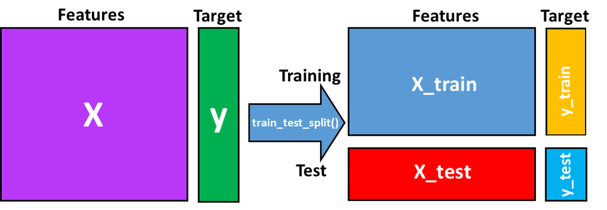

We typically use $80\%$ of our data as the training set, and $20\%$ as the test set. This is a trade off, the more data we have to train with, the better our model will typically be. However, we want as many different test records to evaluate against so we know where our model may be failing. We need the training and test set for both our features X, and our target y. It is important that the data preparation (other than scaling) is performed on both training and test sets.

sklearn comes with a handy method for producing this training test split, unsurprisingly called train_test_split().

```python
from sklearn.model_selection import train_test_split

# Defining a random state allows us to reproduce our split in the future.
train_X, test_X, train_y, test_y = train_test_split(X_np,
                                                    y_np,
                                                    test_size=0.2,
                                                    random_state=123)
# We could do the same with X and y data frames if preferred
```

Lets look at the sizes of our different arrays.

```python
print("Original X data shape: {}\n".format(X_np.shape))

print("Training X data shape: {}\n".format(train_X.shape))

print("Test X data shape: {}\n\n".format(test_X.shape))


print("Original y data shape: {}\n".format(y_np.shape))

print("Training y data shape: {}\n".format(train_y.shape))

print("Test y data shape: {}\n".format(test_y.shape))
```

```
Original X data shape: (679, 4)

Training X data shape: (543, 4)

Test X data shape: (136, 4)


Original y data shape: (679,)

Training y data shape: (543,)

Test y data shape: (136,)
```

We can now use our training data to train our model, and then the testing data to evaluate how well our model performed without each influencing the other.

## 9.8 Random States

In many processes in machine learning we use random processes to do things like shuffle our data, solve equations and produce numbers. This is an important part of machine learning, but with processes being random it means they are not easily reproducible as each time you run the code it will produce a different outcome.

We combat this by fixing the “random state” of the program (or a function), meaning it still does a random process, but it will do the same random process each time it is run.

For example if we want to produce a random number then if we run that code again we can get the same random number the second time we run it. In our case, by fixing the random state of the program we can randomly shuffle our data the same way each time we run the program.

In the above code we passed an argument to the train_test_split function called random_state. By picking a value for the state we set the seed of the random generator meaning the same train test split will be created every time the code is run.

In this course I will typically be assigning a value (always integer) of 123 or similar, this is a personal choice.

This means that other people viewing our work can get the same answers when they run it, making our results reproducible.

## 9.9 Validation Sets

For more more robust processes or advanced, such as those used in deep learning we often will use an addition set of data; the validation set. We therefore have three sets: the training, validation and test set. We use the training data to learn a model, the validation set to tune the model and improve the “hyper-parameters” (which we will discuss later). The test set is used to produce an unbiased estimate of the prediction power of the model.

## 9.10 Summary

From this chapter you should now have an appreciation for the data preparation steps that may be required before features can be given to a model to train. We have covered:

- How to clean data
- How to extract useful features for machine learning
- How to transform data to a different scale
- How to select which features we should use
- Basic data structures useful in sklearn
- How to split our training and test data

Not all methods shown are required for all models or data sets, however, it is important to consider whether each method is needed, and the effect it will have on the data we pass to our model.

**Next Chapter: Regression**

The next chapter will discuss regression, the prediction of numerical values. We will use our *bikes* data in order to predict the count of bikes hired in a day. The chapter will also explain basic evaluation and optimization of models.